# Temperature warming strengthens the mutualism between ghost ants and invasive mealybugs | Scientific Reports

# Temperature warming strengthens the mutualism between ghost ants and invasive mealybugs

- Aiming Zhou,
- Xiaobin Qu,
- Lifan Shan &
- Xin Wang

[*Scientific Reports*](https://www.nature.com/srep) **volume 7**, Article number: 959 (2017) Cite this article

## Abstract

Although the exogenous forces that directly affect the mutualisms between ants and honeydew-producing hemipterans have been well documented, few studies have been focused on the impacts of environmental warming on ant-hemipteran interactions. Here, we investigated how temperature warming affects the mutualism between ghost ant *Tapinoma melanocephalum* and invasive mealybug *Phenacoccus solenopsis* by experimental manipulation of temperature. We found that higher temperatures have significant direct effects on the growth rate of mealybug colony, and the positive effect of ant tending on mealybug colony growth is temperature-dependent. Honeydew excretion by mealybugs was affected by ant tending and temperature warming, and was significantly increased under higher temperature. The effect of ant tending on percentage parasitism was also influenced by temperature warming. Ant performance including tending level, aggression, activity, and honeydew consumption was enhanced by temperature warming, which may provide superior protection to the mealybugs. Our results show that ghost ant-mealybug mutualism is strengthened in a warmer environment. These findings may facilitate the prediction of how each partner in the ant-hemipteran-enemy interactions responds to increasing temperature.

## Introduction

Global mean surface air temperature has been increased by approximately 0.5 °C in the 20<sup>th</sup> century and will be further elevated by 1.7–4.9 °C during 1990 to 2100<sup>1,2,3</sup>. Temperature warming is beginning to have profound effects on the ecosystems<sup>4</sup>. Temperature changes not only directly affect the physiology and behavior of the focal species, but also indirectly influence other species with which the focal species interacts<sup>5</sup>. As poikilotherms, insects appear to quickly respond to the increase of ambient temperature<sup>6</sup>. Climate warming directly affects the development, survival, distribution and abundance of herbivores<sup>7,8,9</sup>. Usually, elevated temperature increases insect overwintering, damage magnitude and range expansion<sup>10</sup>. Besides, climate change may significantly modify the dynamic interactions between plants and insects<sup>11</sup>. Temperature increase may facilitate the growth of herbivores through restraining the concentrations of several phenolic compounds in plant leaves<sup>12</sup>.

Global climate changes are significantly altering multi-species interactions and the structure of ecological communities. Most of the studies have been focused on the effects of increase in CO<sub>2</sub>, which can directly affect plant physiology and indirectly alter the interactions among plants, herbivores and pathogens<sup>13</sup>. Currently, the effects of CO<sub>2</sub> increase on insect feeding behaviors<sup>14</sup>, phytohormone-mediated defenses<sup>14, 15</sup>, and secondary metabolite-mediated resistance<sup>13, 16, 17</sup> have been clearly elucidated. In contrast, the effect of temperature warming on multiple trophic levels has received relatively less attention. Environmental temperature can regulate a number of important biological processes and species interactions. Temperature changes can alter the consumption, growth and survival of insect herbivores, suggesting that temperature-driven impacts on herbivory could influence plant community composition or nutrient cycling<sup>18</sup>. However, there have been few studies addressing the effects of temperature rising on the interspecies interaction at the community level so far.

Reciprocally beneficial interaction between ants and hemipterans is a common phenomenon which plays key roles in the functioning of ecosystems<sup>19,20,21</sup>. This mutual interaction can be strongly influenced by the local neighborhood in which it occurs. The benefits provided by one mutualist species to another can vary along with the changes in biotic factors, such as the density of associated species, seasonality, spatial distribution, identity of species involved and quality of host plants<sup>22,23,24,25,26,27</sup>. In contrast, there have been very few studies about the direct effects of abiotic factors on ant-hemipteran-enemy-host plant interaction patterns. Multiple abiotic factors often influence the interspecies interactions and species coexistence patterns. For instance, temperature variation may modify both ant foraging behavior and aggression, thereby changing the competitive interactions and species co-occurrence patterns<sup>28</sup>. Increase of environmental temperature can promote the ingestion dynamics through directly affecting the sucking pump muscles in the nectarivorous ants *Camponotus mus* <sup>29</sup>. Surface temperature is the main regulatory factor that determines the departure rate of harvester ants *Messor barbarus*, and the activity of worker ants is positively correlated with surface temperature<sup>30</sup>. Some ant species forage more frequently and recruit foragers faster under warmer conditions<sup>31</sup>. Moreover, ant foraging frequency mediates the tending level and protection ability for hemipterans<sup>32, 33</sup>. Benefits to hemipterans are positively and linearly related to ant tending level<sup>26, 34, 35</sup>. Aphids directly respond to elevated temperature with decreased developmental time and reduced adult and progeny weight<sup>36, 37</sup>. Pea Aphid, *Acyrthosiphon pisum*, ingested fluid from sieve element cells less frequently when exposed to extreme temperatures (such as 5 °C and 35 °C) than when exposed to other temperatures. Aphids at optimal temperatures (25–30 °C) ingested fluid from sieve elements for a longer period, probed for a longer time, and produced more offspring than those under other temperatures<sup>38</sup>, suggesting that probing behavior of aphids is enhanced under temperature warming. Besides, plant volatile emissions induced by herbivory are quantitatively related to the degree of herbivore ingestion and the extent of damage<sup>39, 40</sup>, and these varied volatiles play key roles in the host location of predators and parasitoids<sup>41</sup>. These previous studies suggest that temperature increase can considerably influence the concerned species and may bring profound chain effects to the interaction species. However, most of these studies only separately explored the effects on a single species in different research systems, and there have been very few studies dealing with the chain effects on related species and their interspecific interactions in the same research system. The integrated effects of temperature increase on the complex interactions among multiple trophic levels remain largely unknown.

The mutualisms between ants and hemipterans have been well documented. Ant tending improves the survival and colony growth of hemipterans, primarily by protecting the hemipterans from the attack by natural enemies. As a return, the ants receive large amounts of honeydew in a consumer-resource mutualism<sup>19, 42,43,44,45,46</sup>. This mutual relationship is stable when the trade-off between the cost and benefit is in balance<sup>47</sup>. Currently, many studies have documented that these steady interactions are mediated by numerous biotic factors<sup>23, 34, 35, 48,49,50,51,52,53</sup>. Both mealybug *Phenacoccus solenopsis* Tinsley (Hemiptera: Pseudococcidae) and ghost ant *Tapinoma melanocephalum* (Fabricius) (Hymenoptera: Formicidae) are important invasive species in China, which have established a close mutualistic relationship in the ecosystem<sup>54</sup>. Our previous study also showed that the mutualism between ghost ants and invasive mealybugs is significantly affected by the quality of host plant<sup>26</sup>. In contrast, few studies have reported the effects of temperature warming on ant-hemipteran-natural enemy interactions. Understanding how each partner in the ant-hemipteran-enemy interactions responds to changing temperature is critical to the clarification of the important ecological interactions mediated by climatic changes. We hypothesized that temperature warming would positively affect ghost ant-mealybug mutualism. In this study, we tested how temperature warming affects ant-hemipteran-parasitoid interactions, using the interactions among ghost ant *T*. *melanocephalum*-invasive mealybug *P*. *solenop*sis- aggressive parasitoid *Aenasius bambawalei* as a model system. As a result, the effects of temperature warming on the benefits to the mealybug, parasitism, ant performance, and integrated effects on ghost ant-mealybug mutualism were clarified.

## Materials and Methods

### Plants and Insects

Cotton plants were cultivated in plastic flowerpots (18 cm × 14 cm × 17 cm) in greenhouse. Each plant was approximately 35–40 cm in height and had 15 true leaves. Colonies of *P*. *solenopsis* were collected from the experimental field of Huazhong Agricultural University (HZAU, Wuhan, Hubei province, China) and reared on cotton plants in the laboratory. The 1<sup>st</sup> instar mealybug nymphs were inoculated on the cotton and raised for 4–5 generations. The mealybug colonies were reared in greenhouse (temperature, 28 ± 1 °C; relative humidity, 60–70%; under an LD: 16:8 h photocycle). Colonies of ghost ants were collected from the suburb of Wuhan. The colonies were separated into a number of subcolonies. Each subcolony included one queen, adult workers (approximately 1500 individuals), pupae, larvae, and eggs. The ants were placed in plastic petri dish with plaster (6 cm in diameter), which served as an artificial nest. Ant subcolonies were maintained with distilled water plus a 10% honey solution, which was distributed through tubes. The parasitoid *A*. *bambawalei* was collected from the cotton field of HZAU. The parasitoid arrived as mummified mealybugs (parasitized by *A*. *bambawalei*) and separated into gel capsules (10 mm in length) until adult emergence. After emergence, the wasps were randomly paired and allowed to copulate. Copulation was observed in all pairings, and the fertilized female wasps were used in the experiments 24 h after the initial pairing. The larvae of the predator *Harmonia axyridis* were collected from cotton in the field. The ladybeetles were fed with mealybug nymphs in the laboratory at 28 ± 1 °C and maintained under an LD 16:8 h photocycle.

## Experimental Design

### Effects of ant tending, parasitoid and variation in temperature on the benefits to mealybugs

A full-factorial 3-way design was used in the experiment following the protocol of Barton and Ives<sup>5</sup>. The effects of ant tending, parasitoid and increasing temperature on mealybug colony growth were observed and measured. There were 16 combinations of ant tending (present/absent) × parasitoids (present/absent) × temperature (23 °C/26 °C/29 °C/32 °C). Each combination was repeated 12 times. We transferred 60 2<sup>nd</sup> instar mealybugs to cotton plants and allowed them to acclimate and feed for 24 h. Each flowerpot was placed in a plastic container (50 × 40 × 16 cm) and covered by a cage with nylon netting (70 × 70 × 100 cm).

A subcolony of ghost ants was placed in each plastic flowerpot, and then the ants established new nests in the soil immediately. Worker ants could travel to forage for food through the plant trunk. The ants were given two mealworms and water (50 mL) every two days. After 24 h, two fertilized female parasitoids were placed on each selected plant. The experiments lasted for 8 weeks. The numbers of surviving and mummified mealybugs and the number of tending ants on the plant were counted every week. The effects of ant tending, parasitoid and increasing temperature on the colony growth rate of mealybugs were analyzed. The colony growth rate of mealybugs was defined as the final population density divided by the initial population density. The parasitism rate was defined as the number of mummified mealybugs divided by the total number of mealybugs (mummified and surviving mealybugs) on each plant. The mummified mealybugs were easily identified by the decreasing wax and the body color of the mealybugs. We defined the ant tending level as the mean number of tending ants per mealybug.

### Effects of temperature warming on ant aggression

Four temperature treatments (23 °C/26 °C/29 °C/32 °C) were also used in this experiment. Each combination was replicated 15 times. We transferred 60 2<sup>nd</sup> instar mealybugs to each individual cotton plant. After 24 h, two ladybeetle larvae were placed on the plants as predators. As previously described, a subcolony of ghost ants was placed in each plastic flowerpot after another 24 h. We recorded the time it took for an ant to make physical contact with the ladybeetle. We also observed the ant activities under different temperature treatments. Ant foraging activity on the plants was determined by counting the number of foraging ants moving up and down the plant trunk for 3 min.

### Effects of ant tending and temperature warming on honeydew excretion by mealybugs

In this experiment, we tested the effects of temperature warming on the weight of honeydew drops excreted by mealybugs. This experiment also crossed two ant treatments (ant tending and no ant) with four temperature treatments (23 °C/26 °C/29 °C/32 °C). There were 8 combinations and each combination was repeated 6 times. Sixty 3<sup>rd</sup> instar mealybugs were transferred to cotton plant. Ant colonies were placed in plastic flowerpots after 24 h. We sampled the honeydew present on the anus of the mealybugs and cotton plant using filter papers, which had been pre-weighed and dried off at 40 °C for 24 h. Honeydew was sampled at one hour intervals for 6 h (from 9 a.m. to 3 p.m.) for one week. All honeydew-adsorbed filter papers were re-weighed using microbalance (Sartorius, BS, 224 S). The honeydew available per mealybug was determined as the average difference in the mass of the filter papers before and after the adsorption of honeydew. The total mass of honeydew was calculated when the collections were finished.

### Effects of temperature warming on honeydew consumption by ghost ants

We also determined the consumption of honeydew by ghost ants under the temperature gradient (23 °C/26 °C/29 °C/32 °C). Sixty 3<sup>rd</sup> instar mealybugs were transferred to cotton plant. Ant colony was placed in each plastic flowerpot after 24 h. We weighed 30 ants exiting the ant nest and moving towards the mealybugs (traveling up) and another 30 ants that tended the mealybugs or fed on honeydew and carried honeydew away towards the ant nest (traveling down) by using a microbalance (Sartorius, BS, 224 S). The honeydew consumption by ghost ants was calculated as the difference in mean weights between the two ant groups. Each treatment was repeated 12 times.

### Statistical Analyses

To satisfy the preconditions of variance analysis, the data were transformed. The growth rate of the mealybug colony, ant attack time and ant activity were log-transformed; the percentage of parasitism on the mealybugs was treated by the arcsine square root-transformation; and the ant tending level was treated by the square root-transformation. When the data were normally distributed and had similar variances, an analysis of variance (ANOVA) using the Type III sum of squares was performed to compare the means among all measured variables. When the ANOVA results were significant, multiple comparisons of means were performed with Tukey HSD post-hoc analysis. Paired sample t-test was performed to analyze the difference in weights between traveling-down and traveling-up ants. We used the non-parametric Kruskal-Wallis test to compare the median of honeydew consumption by ants under different temperature treatments, and also the Mann-Whitney test (or the two-sample Kolmogorov-Smirnov test) was performed for multiple comparisons among different groups if the results of the Kruskal-Wallis test showed significant differences at 0.05 significance level. All statistical analyses were conducted using SPSS version 14.0 (SPSS Inc., Chicago, IL).

## Results

### Colony growth of mealybugs

**Figure 1**

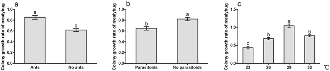

Effect of ant tending, the presence of parasitoids, temperature warming on mealybug colony growth. (**a**) Ant tending; (**b**) Parasitoid; (**c**) Temperature. Results are expressed as the means ± SE. Bars sharing the same letters indicate no significant differences between the treatments (*P* > 0.05).

[Full size image](https://www.nature.com/articles/s41598-017-01137-0/figures/1)

### Parasitism of mealybugs

**Figure 2**

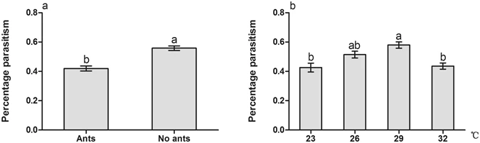

[Full size image](https://www.nature.com/articles/s41598-017-01137-0/figures/2)

### Ant tending level

**Figure 3**

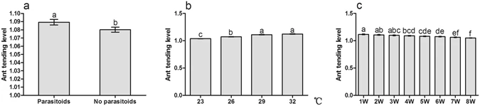

Effect of the presence of parasitoids, temperature warming, and investigation date on ant tending level. (**a**) Parasitoid; (**b**) Temperature; (**c**) Investigation date. Results are expressed as the means ± SE. Bars sharing the same letters indicate no significant differences between the treatments (*P* > 0.05).

[Full size image](https://www.nature.com/articles/s41598-017-01137-0/figures/3)

### Ant aggression

Temperature warming improved the aggression and activity of ghost ants. There were significant differences in ant aggression among different temperature treatments (F = 27.709, *df* = 3, *P* < 0.001). Ants could make physical contact with the ladybeetle more quickly with temperature warming, and were more aggressive towards the intruding predators at 32 °C compared with at other temperatures (Fig. 4a). There were also significant differences in ant activity at different temperatures (F = 24.617, *df* = 3, *P* < 0.001). Ant foraging frequency at 29 °C and 32 °C was higher than that at 26 °C and 23 °C, while was not significantly different between 29 °C and 32 °C (Fig. 4b).

**Figure 4**

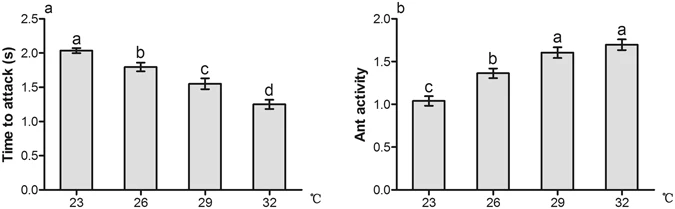

Effect of temperature warming on ants attacking ladybeetles. Results are expressed as the means ± SE. Bars sharing the same letters indicate no significant differences between the treatments (*P* > 0.05).

[Full size image](https://www.nature.com/articles/s41598-017-01137-0/figures/4)

### Honeydew production by mealybugs

**Figure 5**

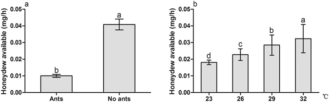

Effect of ant tending and temperature warming on the available honeydew mass excreted by mealybug. (**a**) Ant tending; (**b**) Temperature. Results are expressed as the means ± SE. Bars sharing the same letters indicate no significant differences between the treatments (*P* > 0.05).

[Full size image](https://www.nature.com/articles/s41598-017-01137-0/figures/5)

### Honeydew consumption by ghost ants

Ants traveling down weighed more than ants traveling up at each temperature (Fig. 6a, t = −13.124, *P* < 0.001; t = −12.452, *P* < 0.001; t = −12.569, *P* < 0.001; t = −19.380, *P* < 0.001). Honeydew consumption by ghost ants increased with increasing temperature. Ants harvested more honeydew at 32 °C and 29 °C than at 26 °C and 23 °C (Fig. 6b, *χ* <sup>2</sup> = 36.332, *df* = 3, *P* < 0.001).

**Figure 6**

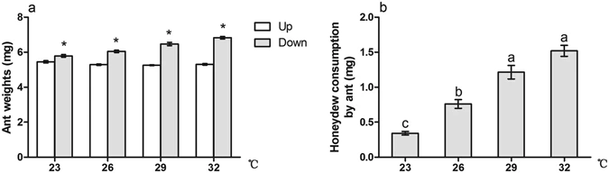

Effect of temperature warming on the honeydew consumption by ant. (**a**) Difference of ant weights between traveling down and traveling up; (**b**) Temperature. Results are expressed as the means ± SE. Asterisk (*) on bars indicate significant differences in the ant weights between travel up and travel down (*P* < 0.05). Bars sharing the same letters indicate no significant differences between the treatments (*P* > 0.05).

[Full size image](https://www.nature.com/articles/s41598-017-01137-0/figures/6)

## Discussion

The net effect of environmental perturbation on species in interconnected ecological communities directly or indirectly influences the interactions among species<sup>5</sup>. The interspecies interaction patterns in ecosystems are often mediated by multiple abiotic factors. Here, we observed the responses of each partner in ant-mealybug-parasitoid interactions under manipulated temperatures. The results show that temperature warming has positive effects on mealybug colony growth, honeydew excretion and ant performance, including tending level, aggression and activity. Although both the colony growth and parasitism of mealybugs decreased under extreme temperature (32 °C), ant tending level and aggression were greatly enhanced. It has been demonstrated that there is a positive linear relationship between ant tending level and mealybug colony growth rate<sup>35</sup>, which suggests that temperature warming could promote mealybug colony growth directly or indirectly. Thus, the net effect of temperature warming is to increase mealybug colony by benefiting ghost ant-mealybug mutualism.

Several studies have indicated that the quality and quantity of the honeydew produced by hemipterans play an important role in mediating the stability and outcomes of hemipteran-ant interactions<sup>19, 32, 67</sup>. The most heavily attended aphid species produces the greatest volume of honeydew and the largest amount of total sugars and trisaccharides per unit time<sup>67</sup>. Our results show that honeydew production by mealybugs is largely influenced by ant tending, temperature warming and their interactions. Less honeydew was present in the treatment with ant tending than in the no-ant treatment (Fig. 5a), indicating that ants remove or consume some part of the honeydew. This is in accordance with the significant difference between ants in traveling-down and traveling-up groups (Fig. 6a). Both honeydew excretion by mealybugs and honeydew consumption by ants were increased with temperature warming (Figs 5b and 6b). Sagata and Gibb reported that honeydew production by scale insect *E*. *coriaceus* was significantly affected by ants, but not by temperature, and the weight of honeydew harvested by individual ants even decreased with increasing temperature<sup>46</sup>. They also suggested that *E*. *coriaceus* is likely to have the maximum ingestion at 23 °C; thus, increasing temperature does not result in greater ingestion of sap by *E*. *coriaceus* <sup>46</sup>. Responses to increasing temperature of sap-sucking insects may vary among different species<sup>36,37,38</sup>. Proper temperatures may improve the flow of phloem sap by reducing sap viscosity or by increasing the turgor pressure of the plants<sup>68</sup>. Therefore, whether temperature warming has a positive or negative impact on ant-hemipteran mutualisms may be related to the variation characteristics of honeydew produced by hemipterans. Our findings demonstrate that temperature warming stimulates honeydew excretion by mealybugs and honeydew consumption by ants, suggesting that ghost ant-mealybug association is enhanced under temperature warming. In addition, honeydew quality may also mediate the ant-hemipteran mutualism<sup>26, 67, 69</sup>. Nutritional requirements of the ant colony and ant preference for sap-sucking insects may be influenced by the changes in quantity and quality of the honeydew. The nutritional contents of honeydew excreted by hemipteran can be directly affected by high temperature<sup>70</sup>. On the other hand, plant quality such as nutrients in the phloem may be changed by temperature warming. Although we did not test this possibility here, a previous study has suggested that sugar accumulation in the phloem elements may also be influenced by temperature warming<sup>71</sup>. Therefore, temperature warming may have indirect effects on ant-hemipteran mutualism by influencing the plant quality.

The negative impacts of temperature warming on ecosystems are receiving more and more attention in science and society. Our results suggest that temperature warming improves mealybug colony growth and ghost ant performance. Ghost ant-mealybug mutualism may be enhanced under temperature warming. Abundant populations of these two invasive species are present in various ecosystems in China, and they have been observed to cause serious damage to agriculture and forestry production. Previous studies have shown that the mutualism between the two species promotes the invasion by each species<sup>26, 35, 54, 72</sup>. Our findings indicate that the invasion of these two species may be further exacerbated due to the enhanced mutual association by temperature warming at least in this system. These findings also allow us to predict how each partner in the ant-hemipteran-enemy interactions may respond to increasing temperature.

## References

1. 1.

   Cassman, K. G. Ecological intensification of cereal production systems: yield potential, soil quality, and precision agriculture. *Proc. Natl. Acad. Sci. USA* **96**, 5952–5959, doi:10.1073/pnas.96.11.5952 (1999).

   [ADS](http://adsabs.harvard.edu/cgi-bin/nph-data_query?link_type=ABSTRACT&bibcode=1999PNAS...96.5952C) [CAS](https://www.nature.com/articles/cas-redirect/1%3ACAS%3A528%3ADyaK1MXksFKlur4%253D) [Article](https://doi.org/10.1073%2Fpnas.96.11.5952) [PubMed](http://www.ncbi.nlm.nih.gov/entrez/query.fcgi?cmd=Retrieve&db=PubMed&dopt=Abstract&list_uids=10339523) [PubMed Central](http://www.ncbi.nlm.nih.gov/pmc/articles/PMC34211) Google Scholar
2. 2.

   Intergovernmental Panel on Climate Change In Climate Change 1995: The Science of Climate Change. eds Houghton, J. T., Meira Filho, L. G., Bruce, J., Lee, H., Callender, B. A., Haites, E., Harris, N. & Maskell, K. (Cambridge Univ. Press, Cambridge, UK) (1995).
3. 3.

   Wigley, T. M. & Raper, S. C. Interpretation of high projections for global-mean warming. *Science.* **293**, 451–454, doi:10.1126/science.1061604 (2001).

   [ADS](http://adsabs.harvard.edu/cgi-bin/nph-data_query?link_type=ABSTRACT&bibcode=2001Sci...293..451W) [CAS](https://www.nature.com/articles/cas-redirect/1%3ASTN%3A280%3ADC%252BD3MvhsVOmsw%253D%253D) [Article](https://doi.org/10.1126%2Fscience.1061604) [PubMed](http://www.ncbi.nlm.nih.gov/entrez/query.fcgi?cmd=Retrieve&db=PubMed&dopt=Abstract&list_uids=11463906) Google Scholar
4. 4.

   Colwell, R. K., Brehm, G., Cardelús, C. L., Gilman, A. C. & Longino, J. T. Global warming, elevational range shifts, and lowland biotic attrition in the wet tropics. *Science (Washington, DC).* **322**, 258–61, doi:10.1126/science.1162547 (2008).

   [ADS](http://adsabs.harvard.edu/cgi-bin/nph-data_query?link_type=ABSTRACT&bibcode=2008Sci...322..258C) [CAS](https://www.nature.com/articles/cas-redirect/1%3ACAS%3A528%3ADC%252BD1cXht1Slu7%252FN) [Article](https://doi.org/10.1126%2Fscience.1162547) Google Scholar
5. 5.

   Barton, B. T. & Ives, A. R. Direct and indirect effects of warming on aphids, their predators, and ant mutualists. *Ecology.* **95**, 1479–1484, doi:10.1890/13-1977.1 (2014).

   [Article](https://doi.org/10.1890%2F13-1977.1) [PubMed](http://www.ncbi.nlm.nih.gov/entrez/query.fcgi?cmd=Retrieve&db=PubMed&dopt=Abstract&list_uids=25039213) Google Scholar
6. 6.

   Johns, C. V. & Hughes, L. Interactive effects of CO<sub>2</sub> and temperature on the leaf-miner *Dialectica scalariella* Zeller (Lepidoptera: Gracillariidae) in Paterson’s Curse, *Echium plantagineum* (Boraginnaceae). *Global Change Biology.* **8**, 142–152, doi:10.1046/j.1365-2486.2002.00462.x (2002).

   [Article](https://doi.org/10.1046%2Fj.1365-2486.2002.00462.x) Google Scholar
7. 7.

   Crozier, L. Warmer winters drive butterfly range expansion by increasing survivorship. *Ecology.* **85**, 231–241, doi:10.1890/02-0607 (2002).

   [Article](https://doi.org/10.1890%2F02-0607) Google Scholar
8. 8.

   Bale, J. S. *et al*. Herbivory in global climate change research: direct effects of rising temperature on insect herbivores. *Global Change Biology.* **8**, 1–16, doi:10.1046/j.1365-2486.2002.00451.x (2002).

   [Article](https://doi.org/10.1046%2Fj.1365-2486.2002.00451.x) Google Scholar
9. 9.

   Robinet, C. & Roques, A. Direct impacts of recent climate warming on insect populations. *Integrative Zoology.* **5**, 132–142, doi:10.1111/j.1749-4877.2010.00196.x (2010).

   [Article](https://doi.org/10.1111%2Fj.1749-4877.2010.00196.x) [PubMed](http://www.ncbi.nlm.nih.gov/entrez/query.fcgi?cmd=Retrieve&db=PubMed&dopt=Abstract&list_uids=21392331) Google Scholar
10. 10.

    Lu, X. *et al*. Climate warming increases biological control agent impact on a non-target species. *Ecology letters.* **18**, 48–56, doi:10.1111/ele.2014.18.issue-1 (2015).

    [ADS](http://adsabs.harvard.edu/cgi-bin/nph-data_query?link_type=ABSTRACT&bibcode=2015ApJ...802...48L) [Article](https://doi.org/10.1111%2Fele.12391) [PubMed](http://www.ncbi.nlm.nih.gov/entrez/query.fcgi?cmd=Retrieve&db=PubMed&dopt=Abstract&list_uids=25376303) Google Scholar
11. 11.

    Marquis, M., Del Toro, I. & Pelini, S. L. Insect mutualisms buffer warming effects on multiple trophic levels. *Ecology.* **95**, 9–13, doi:10.1890/13-0760.1 (2014).

    [Article](https://doi.org/10.1890%2F13-0760.1) [PubMed](http://www.ncbi.nlm.nih.gov/entrez/query.fcgi?cmd=Retrieve&db=PubMed&dopt=Abstract&list_uids=24649640) Google Scholar
12. 12.

    Veteli, T. O., Kuokkanen, K., Julkunen-Tiitto, R., Roininen, H. & Tahvanainen, J. Effects of elevated CO<sub>2</sub> and temperature on plant growth and herbivore defensive chemistry. *Global Change Biology.* **8**, 1240–1252, doi:10.1046/j.1365-2486.2002.00553.x (2002).

    [Article](https://doi.org/10.1046%2Fj.1365-2486.2002.00553.x) Google Scholar
13. 13.

    Robinson, E. A., Ryan, G. D. & Newman, J. A. A meta-analytical review of the effects of elevated CO<sub>2</sub> on plant-arthropod interactions highlights the importance of interacting environmental and biological variables. *New Phytol.* **194**, 321–336, doi:10.1111/j.1469-8137.2012.04074.x (2012).

    [CAS](https://www.nature.com/articles/cas-redirect/1%3ACAS%3A528%3ADC%252BC38XmsFChsLg%253D) [Article](https://doi.org/10.1111%2Fj.1469-8137.2012.04074.x) [PubMed](http://www.ncbi.nlm.nih.gov/entrez/query.fcgi?cmd=Retrieve&db=PubMed&dopt=Abstract&list_uids=22380757) Google Scholar
14. 14.

    Guo, H. *et al*. Elevated CO<sub>2</sub> alters the feeding behaviour of the pea aphid by modifying the physical and chemical resistance of *Medicago truncatula*. *Plant Cell Environ.* **37**, 2158–2168, doi:10.1111/pce.2014.37.issue-9 (2014).

    [CAS](https://www.nature.com/articles/cas-redirect/1%3ACAS%3A528%3ADC%252BC2cXht1ChsL%252FE) [Article](https://doi.org/10.1111%2Fpce.12306) [PubMed](http://www.ncbi.nlm.nih.gov/entrez/query.fcgi?cmd=Retrieve&db=PubMed&dopt=Abstract&list_uids=24697655) Google Scholar
15. 15.

    Zavala, J. A., Casteel, C. L., Nabity, P. D., Berenbaum, M. R. & DeLucia, E. H. Role of cysteine proteinase inhibitors in preference of Japanese beetles (*Popillia japonica*) for soybean (*Glycine max*) leaves of different ages and grown under elevated CO<sub>2</sub>. *Oecologia.* **161**, 35–41, doi:10.1007/s00442-009-1360-7 (2009).

    [Article](https://doi.org/10.1007%2Fs00442-009-1360-7) [PubMed](http://www.ncbi.nlm.nih.gov/entrez/query.fcgi?cmd=Retrieve&db=PubMed&dopt=Abstract&list_uids=19418071) Google Scholar
16. 16.

    Sun, Y., Guo, H. & Ge, F. Plant-aphid interactions under elevated CO<sub>2</sub>: some cues from aphid feeding behavior. *Frontiers in plant science.* **7**, 502, doi:10.3389/fpls.2016.00502 (2016).

    [PubMed](http://www.ncbi.nlm.nih.gov/entrez/query.fcgi?cmd=Retrieve&db=PubMed&dopt=Abstract&list_uids=27148325) [PubMed Central](http://www.ncbi.nlm.nih.gov/pmc/articles/PMC4829579) Google Scholar
17. 17.

    Zhang, J. *et al*. Effects of different atmospheric CO<sub>2</sub> concentrations and soil moistures on the populations of bird cherry-oat aphid (*Rhopalosiphum padi*) feeding on spring wheat. *Eur. J. Entomol.* **100**, 521–530, doi:10.14411/eje.2003.080 (2003).

    [Article](https://doi.org/10.14411%2Feje.2003.080) Google Scholar
18. 18.

    Lemoine, N. P., Drews, W. A., Burkepile, D. E. & Parker, J. D. Increased temperature alters feeding behavior of a generalist herbivore. *Oikos.* **122**, 1669–1678, doi:10.1111/more.2013.122.issue-12 (2013).

    [Article](https://doi.org/10.1111%2Fj.1600-0706.2013.00457.x) Google Scholar
19. 19.

    Styrsky, J. D. & Eubanks, M. D. Ecological consequences of interactions between ants and honeydew-producing insects. *Proceedings of the Royal Society B: Biological Sciences.* **274**, 151–164, doi:10.1098/rspb.2006.3701 (2007).

    [Article](https://doi.org/10.1098%2Frspb.2006.3701) [PubMed](http://www.ncbi.nlm.nih.gov/entrez/query.fcgi?cmd=Retrieve&db=PubMed&dopt=Abstract&list_uids=17148245) Google Scholar
20. 20.

    Brightwell, R. J. & Silverman, J. Invasive Argentine ants reduce fitness of red maple via a mutualism with an endemic coccid. *Biol. Invasions.* **12**, 2051–2057, doi:10.1007/s10530-009-9607-0 (2010).

    [Article](https://doi.org/10.1007%2Fs10530-009-9607-0) Google Scholar
21. 21.

    Wilder, S. M., Holway, D. A., Suarez, A. V., LeBrun, E. G. & Eubanks, M. D. Intercontinental differences in resource use reveal the importance of mutualisms in fire ant invasions. *Proc. Natl. Acad. Sci. USA* **108**, 20639–20644, doi:10.1073/pnas.1115263108 (2011).

    [ADS](http://adsabs.harvard.edu/cgi-bin/nph-data_query?link_type=ABSTRACT&bibcode=2011PNAS..10820639W) [CAS](https://www.nature.com/articles/cas-redirect/1%3ACAS%3A528%3ADC%252BC38XjvV2hsw%253D%253D) [Article](https://doi.org/10.1073%2Fpnas.1115263108) [PubMed](http://www.ncbi.nlm.nih.gov/entrez/query.fcgi?cmd=Retrieve&db=PubMed&dopt=Abstract&list_uids=22143788) [PubMed Central](http://www.ncbi.nlm.nih.gov/pmc/articles/PMC3251143) Google Scholar
22. 22.

    Augspurger, C. K. Reproductive synchrony of a tropical shrub: experimental studies on effects of pollinators and seed predation on *Hybanthus prunifolius* (Violaceae). *Ecology.* **62**, 775–788, doi:10.2307/1937745 (1981).

    [Article](https://doi.org/10.2307%2F1937745) Google Scholar
23. 23.

    Cushman, J. H. & Whitham, T. G. Conditional mutualism in a membracid-ant association: temporal, age-specifc, and density-dependent effects. *Ecology.* **4**, 1040–1047, doi:10.2307/1941372 (1989).

    [Article](https://doi.org/10.2307%2F1941372) Google Scholar
24. 24.

    Moreira, V. S. & Del-Claro, K. The outcomes of an ant-treehopper association on *Solanum lycocarpum* St. Hill: increased membracid fecundity and reduced damage by chewing herbivores. *Neotropical Entomology.* **34**, 881–887, doi:10.1590/S1519-566X2005000600002 (2005).

    [Article](https://doi.org/10.1590%2FS1519-566X2005000600002) Google Scholar
25. 25.

    Fagundes, R., Ribeiro, S. P. & Del-Claro, K. Tending-ants increase survivorship and reproductive success of *Calloconophora pugionata* Drietch (Hemiptera, Membracidae), a trophobiont herbivore of *Myrcia obovata* O. Berg (Myrtales, Myrtaceae). *Sociobiology.* **60**, 11–19, doi:10.13102/sociobiology.v60i1 (2013).

    [Article](https://doi.org/10.13102%2Fsociobiology.v60i1.11-19) Google Scholar
26. 26.

    Zhou, A. M., Kuang, B. Q. & Gao, Y. R. Does the host plant affect the benefits from mutualisms? The invasive mealybug and ghost ant association. *Ecological Entomology.* **40**, 782–786, doi:10.1111/een.12258 (2015).

    [Article](https://doi.org/10.1111%2Feen.12258) Google Scholar
27. 27.

    Pepi, A. A., Broadley, H. J. & Elkinton, J. S. Density-dependent effects of larval dispersal mediated by host plant quality on populations of an invasive insect. *Oecologia.* **182**, 499–509, doi:10.1007/s00442-016-3689-z (2016).

    [Article](https://doi.org/10.1007%2Fs00442-016-3689-z) [PubMed](http://www.ncbi.nlm.nih.gov/entrez/query.fcgi?cmd=Retrieve&db=PubMed&dopt=Abstract&list_uids=27378097) Google Scholar
28. 28.

    Barbieri, R. F., Grangier, J. & Lester, P. J. Synergistic effects of temperature, diet and colony size on the competitive ability of two ant species. *Austral Ecology.* **40**, 90–99, doi:10.1111/aec.2015.40.issue-1 (2015).

    [Article](https://doi.org/10.1111%2Faec.12176) Google Scholar
29. 29.

    Falibene, A. & Josens, R. Environmental temperature affects the dynamics of ingestion in the nectivorous ant *Camponotus mus*. *Journal of insect physiology.* **71**, 14–20, doi:10.1016/j.jinsphys.2014.09.011 (2014).

    [CAS](https://www.nature.com/articles/cas-redirect/1%3ACAS%3A528%3ADC%252BC2cXhslehsbfJ) [Article](https://doi.org/10.1016%2Fj.jinsphys.2014.09.011) [PubMed](http://www.ncbi.nlm.nih.gov/entrez/query.fcgi?cmd=Retrieve&db=PubMed&dopt=Abstract&list_uids=25285641) Google Scholar
30. 30.

    Azcárate, F. M., Kovacs, E. & Peco, B. Microclimatic conditions regulate surface activity in harvester ants *Messor barbarus*. *Journal of Insect Behavior.* **20**, 315–329, doi:10.1007/s10905-007-9074-3 (2007).

    [Article](https://doi.org/10.1007%2Fs10905-007-9074-3) Google Scholar
31. 31.

    Stuble, K. L. *et al*. Foraging by forest ants under experimental climatic warming: a test at two sites. *Ecology and Evolution* **3**, 482–491, doi:10.1002/ece3.473 (2013).

    [Article](https://doi.org/10.1002%2Fece3.473) [PubMed](http://www.ncbi.nlm.nih.gov/entrez/query.fcgi?cmd=Retrieve&db=PubMed&dopt=Abstract&list_uids=23531642) [PubMed Central](http://www.ncbi.nlm.nih.gov/pmc/articles/PMC3605839) Google Scholar
32. 32.

    Stadler, B. & Dixon, A. F. Ecology and evolution of aphid-ant interactions. *Annual Review of Ecology, Evolution, and Systematics.* **36**, 345–372, doi:10.1146/annurev.ecolsys.36.091704.175531 (2005).

    [Article](https://doi.org/10.1146%2Fannurev.ecolsys.36.091704.175531) Google Scholar
33. 33.

    Flatt, T. & Weisser, W. W. The effects of mutualistic ants on aphid life history traits. *Ecology.* **81**, 3522–3529, doi:10.1890/0012-9658(2000)081[3522:TEOMAO]2.0.CO;2 (2000).

    [Article](https://doi.org/10.1890%2F0012-9658%282000%29081%5B3522%3ATEOMAO%5D2.0.CO%3B2) Google Scholar
34. 34.

    Breton, L. M. & Addicott, J. F. Density-dependent mutualism in an aphid-ant interaction. *Ecology.* **73**, 2175–2180, doi:10.2307/1941465 (1992).

    [Article](https://doi.org/10.2307%2F1941465) Google Scholar
35. 35.

    Zhou, A. M., Kuang, B. Q., Gao, Y. R. & Liang, G. W. Density-dependent benefits in ant-hemipteran mutualism? The case of the ghost ant *Tapinoma melanocephalum* (Hymenoptera: Formicidae) and the invasive mealybug *Phenacoccus solenopsis* (Hemiptera: Pseudococcidae). *PloS One.* **10**, e0123885, doi:10.1371/journal.pone.0123885 (2015).

    [Article](https://doi.org/10.1371%2Fjournal.pone.0123885) [PubMed](http://www.ncbi.nlm.nih.gov/entrez/query.fcgi?cmd=Retrieve&db=PubMed&dopt=Abstract&list_uids=25886510) [PubMed Central](http://www.ncbi.nlm.nih.gov/pmc/articles/PMC4401700) Google Scholar
36. 36.

    Himanen, S. J. *et al*. Interactions of elevated carbon dioxide and temperature with aphid feeding on transgenic oilseed rape: Are *Bacillus thuringiensis* (Bt) plants more susceptible to nontarget herbivores in future climate? *Global Change Biology.* **14**, 1437–1454, doi:10.1111/j.1365-2486.2008.01574.x (2008).

    [Article](https://doi.org/10.1111%2Fj.1365-2486.2008.01574.x) Google Scholar
37. 37.

    Flynn, D. F., Sudderth, E. A. & Bazzaz, F. A. Effects of aphid herbivory on biomass and leaf-level physiology of *Solanum dulcamara* under elevated temperature and CO<sub>2</sub>. *Environmental and Experimental Botany.* **56**, 10–18, doi:10.1016/j.envexpbot.2004.12.001 (2006).

    [CAS](https://www.nature.com/articles/cas-redirect/1%3ACAS%3A528%3ADC%252BD28Xhtlaktrs%253D) [Article](https://doi.org/10.1016%2Fj.envexpbot.2004.12.001) Google Scholar
38. 38.

    McLean, D. L. & Kinsey, M. G. Probing behavior of the pea aphid, *Acyrthosiphon pisum*. III. Effect of temperature differences on certain probing activities. *Annals of the Entomological Society of America.* **61**, 927–933, doi:10.1093/aesa/61.4.927 (1968).

    [Article](https://doi.org/10.1093%2Faesa%2F61.4.927) Google Scholar
39. 39.

    Niinemets, Ü., Kännaste, A. & Copolovici, L. Quantitative patterns between plant volatile emissions induced by biotic stresses and the degree of damage. *Frontiers in Plant Science.* **4**, 262, doi:10.3389/fpls.2013.00262 (2013).

    [Article](https://doi.org/10.3389%2Ffpls.2013.00262) [PubMed](http://www.ncbi.nlm.nih.gov/entrez/query.fcgi?cmd=Retrieve&db=PubMed&dopt=Abstract&list_uids=23888161) [PubMed Central](http://www.ncbi.nlm.nih.gov/pmc/articles/PMC3719043) Google Scholar
40. 40.

    Copolovici, L., Kaennaste, A., Remmel, T., Vislap, V. & Niinemets, U. Volatile emissions from *Alnus glutionosa* induced by herbivory are quantitatively related to the extent of damage. *Journal of Chemical Ecology.* **37**, 18–28, doi:10.1007/s10886-010-9897-9 (2011).

    [CAS](https://www.nature.com/articles/cas-redirect/1%3ACAS%3A528%3ADC%252BC3MXht1ClsL0%253D) [Article](https://doi.org/10.1007%2Fs10886-010-9897-9) [PubMed](http://www.ncbi.nlm.nih.gov/entrez/query.fcgi?cmd=Retrieve&db=PubMed&dopt=Abstract&list_uids=21181243) Google Scholar
41. 41.

    Girling, R. D. *et al*. Parasitoids select plants more heavily infested with their caterpillar hosts: a new approach to aid interpretation of plant headspace volatiles. *Proceedings of the Royal Society B: Biological Sciences.* **278**, 2646–2653, doi:10.1098/rspb.2010.2725 (2011).

    [CAS](https://www.nature.com/articles/cas-redirect/1%3ACAS%3A528%3ADC%252BC3MXht1ejtrvE) [Article](https://doi.org/10.1098%2Frspb.2010.2725) [PubMed](http://www.ncbi.nlm.nih.gov/entrez/query.fcgi?cmd=Retrieve&db=PubMed&dopt=Abstract&list_uids=21270031) [PubMed Central](http://www.ncbi.nlm.nih.gov/pmc/articles/PMC3136836) Google Scholar
42. 42.

    Way, M. J. Mutualism between ants and honeydew producing homoptera. *Annual Review of Entomology.* **8**, 307–344, doi:10.1146/annurev.en.08.010163.001515 (1963).

    [Article](https://doi.org/10.1146%2Fannurev.en.08.010163.001515) Google Scholar
43. 43.

    Kaplan, I. & Eubanks, M. D. Disruption of cotton aphid (Homoptera: Aphididae)-natural enemy dynamics by red imported fire ants (Hymenoptera: Formicidae). *Environmental Entomology.* **31**, 1175–1183, doi:10.1603/0046-225X-31.6.1175 (2002).

    [Article](https://doi.org/10.1603%2F0046-225X-31.6.1175) Google Scholar
44. 44.

    Yao, I., Shibao, H. & Akimoto, S. I. Costs and benefits of ant attendance to the drepanosiphid aphid *Tuberculatus quercicola*. *Oikos.* **89**, 3–10, doi:10.1034/j.1600-0706.2000.890101.x (2000).

    [Article](https://doi.org/10.1034%2Fj.1600-0706.2000.890101.x) Google Scholar
45. 45.

    Wilder, S. M., Barnum, T. R., Holway, D. A., Suarez, A. V. & Eubanks, M. D. Introduced fire ants can exclude native ants from critical mutualist-provided resources. *Oecologia.* **172**, 197–205, doi:10.1007/s00442-012-2477-7 (2013).

    [Article](https://doi.org/10.1007%2Fs00442-012-2477-7) [PubMed](http://www.ncbi.nlm.nih.gov/entrez/query.fcgi?cmd=Retrieve&db=PubMed&dopt=Abstract&list_uids=23053235) Google Scholar
46. 46.

    Sagata, K. & Gibb, H. The effect of temperature increases on an ant-hemiptera-plant interaction. *PloS One.* **11**, e0155131, doi:10.1371/journal.pone.0155131 (2016).

    [Article](https://doi.org/10.1371%2Fjournal.pone.0155131) [PubMed](http://www.ncbi.nlm.nih.gov/entrez/query.fcgi?cmd=Retrieve&db=PubMed&dopt=Abstract&list_uids=27434232) [PubMed Central](http://www.ncbi.nlm.nih.gov/pmc/articles/PMC4951116) Google Scholar
47. 47.

    Bronstein, J. L., Wilson, W. G. & Morris, W. F. Ecological dynamics of mutualist/antagonist communities. *The American Naturalist.* **162**, S24–S39, doi:10.1086/378645 (2003).

    [Article](https://doi.org/10.1086%2F378645) [PubMed](http://www.ncbi.nlm.nih.gov/entrez/query.fcgi?cmd=Retrieve&db=PubMed&dopt=Abstract&list_uids=14583855) Google Scholar
48. 48.

    Morales, M. A. Mechanisms and density dependence of benefit in an ant-membracid mutualism. *Ecology.* **81**, 482–489 (2000).

    Google Scholar
49. 49.

    Mooney, K. A. & Agrawal, A. A. Plant genotype shapes ant-aphid interactions: implications for community structure and indirect plant defense. *The American Naturalist.* **171**, E195–E205, doi:10.1086/587758 (2008).

    [Article](https://doi.org/10.1086%2F587758) [PubMed](http://www.ncbi.nlm.nih.gov/entrez/query.fcgi?cmd=Retrieve&db=PubMed&dopt=Abstract&list_uids=18419551) Google Scholar
50. 50.

    Yao, I. Effect of summer flush leaves of the Daimyo oak, *Quercus dentata*, on density, fecundity and honeydew excretion by the drepanosiphid aphid *Tuberculatus quercicola* (Sternorrhyncha: Aphididae). *European Journal of Entomology.* **101**, 531–538, doi:10.14411/eje.2004.076 (2004).

    [Article](https://doi.org/10.14411%2Feje.2004.076) Google Scholar
51. 51.

    Itioka, T. & Inoue, T. Density-dependent ant attendance and its effects on the parasitism of a honeydew producing scale insect. *Ceroplastes rubens. Oecologia.* **106**, 448–454, doi:10.1007/BF00329700 (1996).

    [Article](https://doi.org/10.1007%2FBF00329700) [PubMed](http://www.ncbi.nlm.nih.gov/entrez/query.fcgi?cmd=Retrieve&db=PubMed&dopt=Abstract&list_uids=28307442) Google Scholar
52. 52.

    Kay, A. D., Scott, S. E., Schade, J. D. & Hobbie, S. E. Stoichiometric relations in an ant-treehopper mutualism. *Ecology Letters.* **7**, 1024–1028, doi:10.1111/ele.2004.7.issue-11 (2004).

    [Article](https://doi.org/10.1111%2Fj.1461-0248.2004.00667.x) Google Scholar
53. 53.

    Bronstein, J. L. Conditional outcomes in mutualistic interactions. *Trends in Ecology & Evolution.* **9**, 214–217, doi:10.1016/0169-5347(94)90246-1 (1994).

    [CAS](https://www.nature.com/articles/cas-redirect/1%3ASTN%3A280%3ADC%252BC3M7itFSmsw%253D%253D) [Article](https://doi.org/10.1016%2F0169-5347%2894%2990246-1) Google Scholar
54. 54.

    Zhou, A. M., Lu, Y. Y., Zeng, L., Xu, Y. J. & Liang, G. W. Does mutualism drive the invasion of two alien species? The case of *Solenopsis invicta* and *Phenacoccus solenopsis*. *PloS One.* **7**, e41856, doi:10.1371/journal.pone.0041856 (2012).

    [ADS](http://adsabs.harvard.edu/cgi-bin/nph-data_query?link_type=ABSTRACT&bibcode=2012PLoSO...741856Z) [CAS](https://www.nature.com/articles/cas-redirect/1%3ACAS%3A528%3ADC%252BC38XhtFSktbvI) [Article](https://doi.org/10.1371%2Fjournal.pone.0041856) [PubMed](http://www.ncbi.nlm.nih.gov/entrez/query.fcgi?cmd=Retrieve&db=PubMed&dopt=Abstract&list_uids=22911859) [PubMed Central](http://www.ncbi.nlm.nih.gov/pmc/articles/PMC3402455) Google Scholar
55. 55.

    Prasad, Y. G., Prabhakar, M., Sreedevi, G., Rao, G. R. & Venkateswarlu, B. Effect of temperature on development, survival and reproduction of the mealybug, *Phenacoccus solenopsis* Tinsley (Hemiptera: Pseudococcidae) on cotton. *Crop protection.* **39**, 81–88, doi:10.1371/journal.pone.0075636 (2012).

    [Article](https://doi.org/10.1016%2Fj.cropro.2012.03.027) Google Scholar
56. 56.

    Wang, Y., Watson, G. W. & Zhang, R. The potential distribution of an invasive mealybug *Phenacoccus solenopsis* and its threat to cotton in Asia. *Agricultural and Forest Entomology.* **12**, 403–416, doi:10.1111/afe.2010.12.issue-4 (2010).

    [Article](https://doi.org/10.1111%2Fj.1461-9563.2010.00490.x) Google Scholar
57. 57.

    Del-Claro, K. & Oliveira, P. S. Conditional outcomes in a neotropical treehopper-ant association: temporal and species-specific variation in ant protection and homopteran fecundity. *Oecologia.* **124**, 156–165, doi:10.1007/s004420050002 (2000).

    [CAS](https://www.nature.com/articles/cas-redirect/1%3ASTN%3A280%3ADC%252BC1czns1KrsQ%253D%253D) [Article](https://doi.org/10.1007%2Fs004420050002) [PubMed](http://www.ncbi.nlm.nih.gov/entrez/query.fcgi?cmd=Retrieve&db=PubMed&dopt=Abstract&list_uids=28308174) Google Scholar
58. 58.

    Daane, K. M., Sime, K. R., Fallon, J. & Cooper, M. L. Impacts of Argentine ants on mealybugs and their natural enemies in California’s coastal vineyards. *Ecological Entomology.* **32**, 583–596, doi:10.1111/een.2007.32.issue-6 (2007).

    [Article](https://doi.org/10.1111%2Fj.1365-2311.2007.00910.x) Google Scholar
59. 59.

    Styrsky, J. D. & Eubanks, M. D. Ecological consequences of interactions between ants and honeydew-producing insects. *Proceedings of the Royal Society of London B: Biological Sciences.* **274**, 151–164, doi:10.1098/rspb.2006.3701 (2007).

    [Article](https://doi.org/10.1098%2Frspb.2006.3701) Google Scholar
60. 60.

    Hall, C. R., Burwell, C. J. & Kitching, R. L. Changes in function and temporal variation in a guild of gall-parasitoids across a temperature gradient in Australian subtropical rainforest. *Austral Ecology.* **41**, 145–153, doi:10.1111/aec.12283 (2016).

    [Article](https://doi.org/10.1111%2Faec.12283) Google Scholar
61. 61.

    Jarrahi, A. & Safavi, S. A. Temperature-dependent functional response and host preference of *Habrobracon hebetor* between fungus-infected and uninfected *Ephestia kuehniella* larvae. *Journal of Stored Products Research.* **67**, 41–48, doi:10.1016/j.jspr.2016.02.001 (2016).

    [Article](https://doi.org/10.1016%2Fj.jspr.2016.02.001) Google Scholar
62. 62.

    Skovgård, H. & Nachman, G. Temperature-dependent functional response of *Spalangia cameroni* (Hymenoptera: Pteromalidae), a parasitoid of *Stomoxys calcitrans* (Diptera: Muscidae). *Environmental Entomology.* **44**, 90–99, doi:10.1093/ee/nvu014 (2015).

    [Article](https://doi.org/10.1093%2Fee%2Fnvu014) [PubMed](http://www.ncbi.nlm.nih.gov/entrez/query.fcgi?cmd=Retrieve&db=PubMed&dopt=Abstract&list_uids=26308810) Google Scholar
63. 63.

    Moayeri, H. R., Madadi, H., Pouraskari, H. & Enkegaard, A. Temperature dependent functional response of *Diaeretiella rapae* (Hymenoptera: Aphidiidae) to the cabbage aphid, *Brevicoryne brassicae* (Hemiptera: Aphididae). *European Journal of Entomology.* **110**, 109–113, doi:10.14411/eje.2013.015 (2013).

    [Article](https://doi.org/10.14411%2Feje.2013.015) Google Scholar
64. 64.

    Wallis, D. I. Aggressive behaviour in the ant, *Formica fusca*. *Animal Behaviour.* **10**, 267–274, doi:10.1016/0003-3472(62)90050-7 (1962).

    [Article](https://doi.org/10.1016%2F0003-3472%2862%2990050-7) Google Scholar
65. 65.

    Sloggett, J. J., Wood, R. A. & Majerus, M. E. Adaptations of *Coccinella magnifica* Redtenbacher, a myrmecophilous coccinellid, to aggression by wood ants (*Formica rufa* group). I. Adult behavioral adaptation, its ecological context and evolution. *Journal of insect behavior.* **11**, 889–904, doi:10.1023/A:1020820428820 (1998).

    [Article](https://doi.org/10.1023%2FA%3A1020820428820) Google Scholar
66. 66.

    Cerdá, X., Retana, J. & Manzaneda, A. The role of competition by dominants and temperature in the foraging of subordinate species in Mediterranean ant communities. *Oecologia.* **117**, 404–412, doi:10.1007/s004420050674 (1998).

    [Article](https://doi.org/10.1007%2Fs004420050674) [PubMed](http://www.ncbi.nlm.nih.gov/entrez/query.fcgi?cmd=Retrieve&db=PubMed&dopt=Abstract&list_uids=28307920) Google Scholar
67. 67.

    Völkl, W., Woodring, J., Fischer, M., Lorenz, M. W. & Hoffmann, K. H. Ant-aphid mutualisms: the impact of honeydew production and honeydew sugar composition on ant preferences. *Oecologia.* **118**, 483–491, doi:10.1007/s004420050751 (1999).

    [Article](https://doi.org/10.1007%2Fs004420050751) [PubMed](http://www.ncbi.nlm.nih.gov/entrez/query.fcgi?cmd=Retrieve&db=PubMed&dopt=Abstract&list_uids=28307416) Google Scholar
68. 68.

    Thomas, D. S., Montagu, K. D. & Conroy, J. P. Changes in wood density of *Eucalyptus camaldulensis* due to temperature-the physiological link between water viscosity and wood anatomy. *Forest Ecology and Management.* **193**, 157–165, doi:10.1016/j.foreco.2004.01.028 (2004).

    [Article](https://doi.org/10.1016%2Fj.foreco.2004.01.028) Google Scholar
69. 69.

    Fischer, M. K. & Shingleton, A. W. Host plant and ants influence honeydew sugar composition of aphids. *Functional Ecology.* **15**, 544–550, doi:10.1046/j.0269-8463.2001.00550.x (2001).

    [Article](https://doi.org/10.1046%2Fj.0269-8463.2001.00550.x) Google Scholar
70. 70.

    Salvucci, M. E., Hendrix, D. L. & Wolfe, G. R. Effect of high temperature on the metabolic processes affecting sorbitol synthesis in the silverleaf whitefly, *Bemisia argentifolii*. *Journal of Insect Physiology.* **45**, 21–27, doi:10.1016/S0022-1910(98)00105-X (1999).

    [CAS](https://www.nature.com/articles/cas-redirect/1%3ACAS%3A528%3ADyaK1MXjslClug%253D%253D) [Article](https://doi.org/10.1016%2FS0022-1910%2898%2900105-X) [PubMed](http://www.ncbi.nlm.nih.gov/entrez/query.fcgi?cmd=Retrieve&db=PubMed&dopt=Abstract&list_uids=12770392) Google Scholar
71. 71.

    Newman, J. A. Climate change and cereal aphids: the relative effects of increasing CO<sub>2</sub> and temperature on aphid population dynamics. *Global Change Biology.* **10**, 5–15, doi:10.1111/gcb.2004.10.issue-1 (2004).

    [Article](https://doi.org/10.1111%2Fj.1365-2486.2003.00709.x) Google Scholar
72. 72.

    Zhou, A. M., Liang, G. W., Zeng, L., Lu, Y. Y. & Xu, Y. J. *Solenopsis invicta* suppress native ant by excluding mutual exploitation from the invasive mealybug, *Phenacoccus solenopsis*. *Pakistan J. Zool.* **49**, 133–141, doi:10.17582/journal.pjz/2017.49.1.133.141 (2017).

    [Article](https://doi.org/10.17582%2Fjournal.pjz%2F2017.49.1.133.141) Google Scholar

[Download references](https://www.nature.com/articles/s41598-017-01137-0-references.ris)

## Acknowledgements

We thank Dr. Hongsong Chen for sample collection. We are also grateful to the anonymous reviewers for their valuable comments on an earlier version of this manuscript. This study was supported and funded by the National Natural Science Foundation of China (grant no. 31401808).

## Author information

### Affiliations

1. Hubei Insect Resources Utilization and Sustainable Pest Management Key Laboratory, College of Plant Science and Technology, Huazhong Agricultural University, Wuhan, 430070, China

   Aiming Zhou, Xiaobin Qu, Lifan Shan & Xin Wang

### Contributions

A.M. Zhou wrote the manuscript; A.M. Zhou, L.F. Shan, and X. Wang analyzed data; A.M. Zhou prepared figures; A.M. Zhou and X.B. Qu provided conception and design of research. A.M. Zhou, L.F. Shan, X. Wang, and X.B. Qu performed the experiments; A.M. Zhou edited and reviewed the manuscript. All authors accepted the final version of the manuscript.

### Corresponding author

Correspondence to [Aiming Zhou](https://www.nature.com/articles/s41598-017-01137-0/email/correspondent/c1/new).

## Ethics declarations

### Competing Interests

The authors declare that they have no competing interests.

## Additional information

**Publisher's note:** Springer Nature remains neutral with regard to jurisdictional claims in published maps and institutional affiliations.

## Rights and permissions

**Open Access** This article is licensed under a Creative Commons Attribution 4.0 International License, which permits use, sharing, adaptation, distribution and reproduction in any medium or format, as long as you give appropriate credit to the original author(s) and the source, provide a link to the Creative Commons license, and indicate if changes were made. The images or other third party material in this article are included in the article’s Creative Commons license, unless indicated otherwise in a credit line to the material. If material is not included in the article’s Creative Commons license and your intended use is not permitted by statutory regulation or exceeds the permitted use, you will need to obtain permission directly from the copyright holder. To view a copy of this license, visit http://creativecommons.org/licenses/by/4.0/.

Reprints and Permissions

## About this article

### Cite this article

Zhou, A., Qu, X., Shan, L. *et al.* Temperature warming strengthens the mutualism between ghost ants and invasive mealybugs. *Sci Rep* **7,** 959 (2017). https://doi.org/10.1038/s41598-017-01137-0

[Download citation](https://www.nature.com/articles/s41598-017-01137-0.ris)

- Received: 22 December 2016
- Accepted: 27 March 2017
- Published: 19 April 2017
- DOI: https://doi.org/10.1038/s41598-017-01137-0

### Share this article

Anyone you share the following link with will be able to read this content:

### Subjects

- [Entomology](https://www.nature.com/subjects/entomology)
- [Invasive species](https://www.nature.com/subjects/invasive-species)

### [Ant–hemipteran association decreases parasitism of Phenacoccus solenopsis by endoparasitoid Aenasius bambawalei](https://doi.org/10.1111/een.12797)

  *Ecological Entomology* (2020)

### Invasion biology of the cotton mealybug, Phenacoccus solenopsis Tinsley: Current knowledge and future directions

  *Journal of Integrative Agriculture* (2019)

### [Elevated temperatures alter an ant‐aphid mutualism](https://doi.org/10.1111/eea.12839)

  *Entomologia Experimentalis et Applicata* (2019)

### [Ant-mealybug mutualism modulates the performance of co-occurring herbivores](https://doi.org/10.1038/s41598-019-49334-3)

  *Scientific Reports* (2019)

### [Left out in the cold: temperature‐dependence of defense in an African ant–plant mutualism](https://doi.org/10.1002/ecy.2712)

  *Ecology* (2019)